# Risk Factor Analysis

## Outcome Variable

**Outcome Variable:** stunted

## Predictor Variables

**Intervention Variable:** nhh

**Adjustment Set:**

unadjusted

## Stratifying Variables

The analysis was stratified on these variable(s):

- agecat
- studyid
- country

## Data Summary

| agecat | studyid | country | A | n | nA | nAY0 | nAY1 |
| --- | --- | --- | --- | --- | --- | --- | --- |
| Birth | ki1000108-IRC | INDIA | 3 or less | 388 | 54 | 51 | 3 |
| Birth | ki1000108-IRC | INDIA | 4-5 | 388 | 150 | 128 | 22 |
| Birth | ki1000108-IRC | INDIA | 6-7 | 388 | 103 | 89 | 14 |
| Birth | ki1000108-IRC | INDIA | 8+ | 388 | 81 | 75 | 6 |
| Birth | ki1017093-NIH-Birth | BANGLADESH | 3 or less | 28 | 7 | 7 | 0 |
| Birth | ki1017093-NIH-Birth | BANGLADESH | 4-5 | 28 | 11 | 10 | 1 |
| Birth | ki1017093-NIH-Birth | BANGLADESH | 6-7 | 28 | 7 | 7 | 0 |
| Birth | ki1017093-NIH-Birth | BANGLADESH | 8+ | 28 | 3 | 3 | 0 |
| Birth | ki1017093c-NIH-Crypto | BANGLADESH | 3 or less | 27 | 8 | 7 | 1 |
| Birth | ki1017093c-NIH-Crypto | BANGLADESH | 4-5 | 27 | 9 | 7 | 2 |
| Birth | ki1017093c-NIH-Crypto | BANGLADESH | 6-7 | 27 | 7 | 5 | 2 |
| Birth | ki1017093c-NIH-Crypto | BANGLADESH | 8+ | 27 | 3 | 3 | 0 |
| 3 months | ki1000108-IRC | INDIA | 3 or less | 407 | 58 | 48 | 10 |
| 3 months | ki1000108-IRC | INDIA | 4-5 | 407 | 156 | 120 | 36 |
| 3 months | ki1000108-IRC | INDIA | 6-7 | 407 | 106 | 83 | 23 |
| 3 months | ki1000108-IRC | INDIA | 8+ | 407 | 87 | 65 | 22 |
| 3 months | ki1000304b-SAS-FoodSuppl | INDIA | 3 or less | 97 | 7 | 4 | 3 |
| 3 months | ki1000304b-SAS-FoodSuppl | INDIA | 4-5 | 97 | 36 | 21 | 15 |
| 3 months | ki1000304b-SAS-FoodSuppl | INDIA | 6-7 | 97 | 35 | 21 | 14 |
| 3 months | ki1000304b-SAS-FoodSuppl | INDIA | 8+ | 97 | 19 | 13 | 6 |
| 3 months | ki1017093-NIH-Birth | BANGLADESH | 3 or less | 570 | 101 | 76 | 25 |
| 3 months | ki1017093-NIH-Birth | BANGLADESH | 4-5 | 570 | 241 | 183 | 58 |
| 3 months | ki1017093-NIH-Birth | BANGLADESH | 6-7 | 570 | 133 | 99 | 34 |
| 3 months | ki1017093-NIH-Birth | BANGLADESH | 8+ | 570 | 95 | 82 | 13 |
| 3 months | ki1017093b-PROVIDE | BANGLADESH | 3 or less | 645 | 126 | 109 | 17 |
| 3 months | ki1017093b-PROVIDE | BANGLADESH | 4-5 | 645 | 298 | 261 | 37 |
| 3 months | ki1017093b-PROVIDE | BANGLADESH | 6-7 | 645 | 136 | 125 | 11 |
| 3 months | ki1017093b-PROVIDE | BANGLADESH | 8+ | 645 | 85 | 72 | 13 |
| 3 months | ki1017093c-NIH-Crypto | BANGLADESH | 3 or less | 728 | 109 | 82 | 27 |
| 3 months | ki1017093c-NIH-Crypto | BANGLADESH | 4-5 | 728 | 330 | 255 | 75 |

[output cut: 118 more lines]

The following strata were considered:

- agecat: 12 months, studyid: ki1000108-IRC, country: INDIA
- agecat: 12 months, studyid: ki1000304b-SAS-FoodSuppl, country: INDIA
- agecat: 12 months, studyid: ki1017093-NIH-Birth, country: BANGLADESH
- agecat: 12 months, studyid: ki1017093b-PROVIDE, country: BANGLADESH
- agecat: 12 months, studyid: ki1017093c-NIH-Crypto, country: BANGLADESH
- agecat: 12 months, studyid: ki1148112-LCNI-5, country: MALAWI
- agecat: 18 months, studyid: ki1000108-IRC, country: INDIA
- agecat: 18 months, studyid: ki1000304b-SAS-FoodSuppl, country: INDIA
- agecat: 18 months, studyid: ki1017093-NIH-Birth, country: BANGLADESH
- agecat: 18 months, studyid: ki1017093b-PROVIDE, country: BANGLADESH
- agecat: 18 months, studyid: ki1017093c-NIH-Crypto, country: BANGLADESH
- agecat: 18 months, studyid: ki1148112-LCNI-5, country: MALAWI
- agecat: 24 months, studyid: ki1000108-IRC, country: INDIA
- agecat: 24 months, studyid: ki1017093-NIH-Birth, country: BANGLADESH
- agecat: 24 months, studyid: ki1017093b-PROVIDE, country: BANGLADESH
- agecat: 24 months, studyid: ki1017093c-NIH-Crypto, country: BANGLADESH
- agecat: 24 months, studyid: ki1148112-LCNI-5, country: MALAWI
- agecat: 3 months, studyid: ki1000108-IRC, country: INDIA
- agecat: 3 months, studyid: ki1000304b-SAS-FoodSuppl, country: INDIA
- agecat: 3 months, studyid: ki1017093-NIH-Birth, country: BANGLADESH
- agecat: 3 months, studyid: ki1017093b-PROVIDE, country: BANGLADESH
- agecat: 3 months, studyid: ki1017093c-NIH-Crypto, country: BANGLADESH
- agecat: 6 months, studyid: ki1000108-IRC, country: INDIA
- agecat: 6 months, studyid: ki1000304b-SAS-FoodSuppl, country: INDIA
- agecat: 6 months, studyid: ki1017093-NIH-Birth, country: BANGLADESH
- agecat: 6 months, studyid: ki1017093b-PROVIDE, country: BANGLADESH
- agecat: 6 months, studyid: ki1017093c-NIH-Crypto, country: BANGLADESH
- agecat: 6 months, studyid: ki1148112-LCNI-5, country: MALAWI
- agecat: 9 months, studyid: ki1000108-IRC, country: INDIA
- agecat: 9 months, studyid: ki1000304b-SAS-FoodSuppl, country: INDIA
- agecat: 9 months, studyid: ki1017093-NIH-Birth, country: BANGLADESH
- agecat: 9 months, studyid: ki1017093b-PROVIDE, country: BANGLADESH
- agecat: 9 months, studyid: ki1017093c-NIH-Crypto, country: BANGLADESH
- agecat: 9 months, studyid: ki1148112-LCNI-5, country: MALAWI
- agecat: Birth, studyid: ki1000108-IRC, country: INDIA
- agecat: Birth, studyid: ki1017093-NIH-Birth, country: BANGLADESH
- agecat: Birth, studyid: ki1017093c-NIH-Crypto, country: BANGLADESH

### Dropped Strata

Some strata were dropped due to rare outcomes:

- agecat: Birth, studyid: ki1000108-IRC, country: INDIA
- agecat: Birth, studyid: ki1017093-NIH-Birth, country: BANGLADESH
- agecat: Birth, studyid: ki1017093c-NIH-Crypto, country: BANGLADESH
- agecat: 3 months, studyid: ki1000304b-SAS-FoodSuppl, country: INDIA
- agecat: 6 months, studyid: ki1000304b-SAS-FoodSuppl, country: INDIA
- agecat: 9 months, studyid: ki1000304b-SAS-FoodSuppl, country: INDIA
- agecat: 12 months, studyid: ki1000304b-SAS-FoodSuppl, country: INDIA
- agecat: 18 months, studyid: ki1000304b-SAS-FoodSuppl, country: INDIA

## Methods Detail

We’re interested in the causal parameters $E[Y_a]$ for all values of $a \in \mathcal{A}$. These parameters represent the mean outcome if, possibly contrary to fact, we intervened to set all units to have $A=a$. Under the randomization and positivity assumptions, these are identified by the statistical parameters $\psi_a=E_W[E_{Y|A,W}(Y|A=a,W)]$. In addition, we’re interested in the mean of $Y$, $E[Y]$ under no intervention (the observed mean). We will estimate these parameters by using SuperLearner to fit the relevant likelihood factors – $E_{Y|A,W}(Y|A=a,W)$ and $p(A=a|W)$, and then updating our likelihood fit using a joint TMLE.

For unadjusted analyses ($W=\{\}$), initial likelihoods were estimated using Lrnr_glm to estimate the simple $E(Y|A)$ and Lrnr_mean to estimate $p(A)$. For adjusted analyses, a small library containing Lrnr_glmnet, Lrnr_xgboost, and Lrnr_mean was used.

Having estimated these parameters, we will then use the delta method to estimate relative risks and attributable risks relative to a prespecified baseline level of $A$.

# Results Detail

## Results Plots

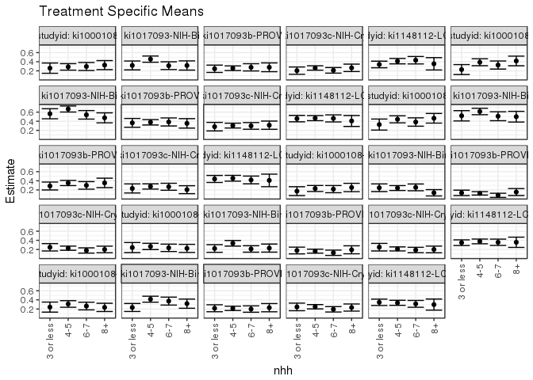

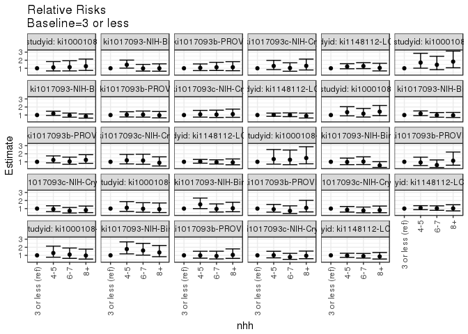

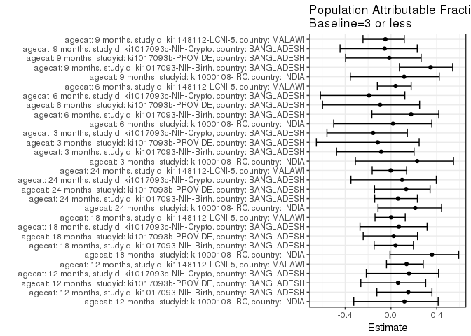

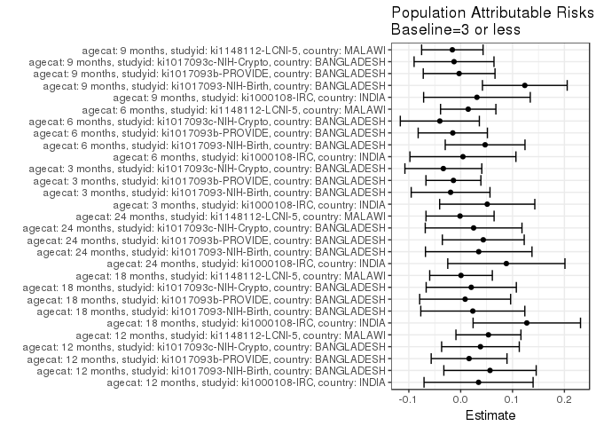

## Results Table

### Parameter: TSM

| agecat | studyid | country | intervention_level | baseline_level | estimate | ci_lower | ci_upper |
| --- | --- | --- | --- | --- | --- | --- | --- |
| 3 months | ki1000108-IRC | INDIA | 3 or less | NA | 0.1724138 | 0.0750806 | 0.2697470 |
| 3 months | ki1000108-IRC | INDIA | 4-5 | NA | 0.2307692 | 0.1645724 | 0.2969661 |
| 3 months | ki1000108-IRC | INDIA | 6-7 | NA | 0.2169811 | 0.1384166 | 0.2955456 |
| 3 months | ki1000108-IRC | INDIA | 8+ | NA | 0.2528736 | 0.1614262 | 0.3443210 |
| 3 months | ki1017093-NIH-Birth | BANGLADESH | 3 or less | NA | 0.2475248 | 0.1632836 | 0.3317659 |
| 3 months | ki1017093-NIH-Birth | BANGLADESH | 4-5 | NA | 0.2406639 | 0.1866453 | 0.2946825 |
| 3 months | ki1017093-NIH-Birth | BANGLADESH | 6-7 | NA | 0.2556391 | 0.1814382 | 0.3298400 |
| 3 months | ki1017093-NIH-Birth | BANGLADESH | 8+ | NA | 0.1368421 | 0.0676713 | 0.2060129 |
| 3 months | ki1017093b-PROVIDE | BANGLADESH | 3 or less | NA | 0.1349206 | 0.0752217 | 0.1946196 |
| 3 months | ki1017093b-PROVIDE | BANGLADESH | 4-5 | NA | 0.1241611 | 0.0866912 | 0.1616309 |
| 3 months | ki1017093b-PROVIDE | BANGLADESH | 6-7 | NA | 0.0808824 | 0.0350230 | 0.1267417 |
| 3 months | ki1017093b-PROVIDE | BANGLADESH | 8+ | NA | 0.1529412 | 0.0763648 | 0.2295175 |
| 3 months | ki1017093c-NIH-Crypto | BANGLADESH | 3 or less | NA | 0.2477064 | 0.1666111 | 0.3288017 |
| 3 months | ki1017093c-NIH-Crypto | BANGLADESH | 4-5 | NA | 0.2272727 | 0.1820271 | 0.2725183 |
| 3 months | ki1017093c-NIH-Crypto | BANGLADESH | 6-7 | NA | 0.1775148 | 0.1198668 | 0.2351628 |
| 3 months | ki1017093c-NIH-Crypto | BANGLADESH | 8+ | NA | 0.2000000 | 0.1283830 | 0.2716170 |
| 6 months | ki1000108-IRC | INDIA | 3 or less | NA | 0.2413793 | 0.1311161 | 0.3516425 |
| 6 months | ki1000108-IRC | INDIA | 4-5 | NA | 0.2658228 | 0.1968544 | 0.3347912 |
| 6 months | ki1000108-IRC | INDIA | 6-7 | NA | 0.2358491 | 0.1549328 | 0.3167654 |
| 6 months | ki1000108-IRC | INDIA | 8+ | NA | 0.2235294 | 0.1348541 | 0.3122047 |
| 6 months | ki1017093-NIH-Birth | BANGLADESH | 3 or less | NA | 0.2210526 | 0.1375322 | 0.3045731 |
| 6 months | ki1017093-NIH-Birth | BANGLADESH | 4-5 | NA | 0.3348018 | 0.2733535 | 0.3962500 |
| 6 months | ki1017093-NIH-Birth | BANGLADESH | 6-7 | NA | 0.2109375 | 0.1401950 | 0.2816800 |
| 6 months | ki1017093-NIH-Birth | BANGLADESH | 8+ | NA | 0.2298851 | 0.1413885 | 0.3183816 |
| 6 months | ki1017093b-PROVIDE | BANGLADESH | 3 or less | NA | 0.1764706 | 0.1024255 | 0.2505157 |
| 6 months | ki1017093b-PROVIDE | BANGLADESH | 4-5 | NA | 0.1624549 | 0.1189787 | 0.2059311 |
| 6 months | ki1017093b-PROVIDE | BANGLADESH | 6-7 | NA | 0.1269841 | 0.0687977 | 0.1851705 |
| 6 months | ki1017093b-PROVIDE | BANGLADESH | 8+ | NA | 0.1923077 | 0.1047700 | 0.2798453 |
| 6 months | ki1017093c-NIH-Crypto | BANGLADESH | 3 or less | NA | 0.2500000 | 0.1667209 | 0.3332791 |
| 6 months | ki1017093c-NIH-Crypto | BANGLADESH | 4-5 | NA | 0.2116564 | 0.1672837 | 0.2560292 |

[output cut: 86 more lines]

### Parameter: E(Y)

| agecat | studyid | country | intervention_level | baseline_level | estimate | ci_lower | ci_upper |
| --- | --- | --- | --- | --- | --- | --- | --- |
| 3 months | ki1000108-IRC | INDIA | NA | NA | 0.2235872 | 0.1830592 | 0.2641152 |
| 3 months | ki1017093-NIH-Birth | BANGLADESH | NA | NA | 0.2280702 | 0.1935943 | 0.2625460 |
| 3 months | ki1017093b-PROVIDE | BANGLADESH | NA | NA | 0.1209302 | 0.0957486 | 0.1461119 |
| 3 months | ki1017093c-NIH-Crypto | BANGLADESH | NA | NA | 0.2142857 | 0.1844587 | 0.2441127 |
| 6 months | ki1000108-IRC | INDIA | NA | NA | 0.2457002 | 0.2038248 | 0.2875757 |
| 6 months | ki1017093-NIH-Birth | BANGLADESH | NA | NA | 0.2681564 | 0.2306532 | 0.3056597 |
| 6 months | ki1017093b-PROVIDE | BANGLADESH | NA | NA | 0.1612350 | 0.1313580 | 0.1911120 |
| 6 months | ki1017093c-NIH-Crypto | BANGLADESH | NA | NA | 0.2097902 | 0.1799252 | 0.2396552 |
| 6 months | ki1148112-LCNI-5 | MALAWI | NA | NA | 0.3627451 | 0.3297365 | 0.3957537 |
| 9 months | ki1000108-IRC | INDIA | NA | NA | 0.2727273 | 0.2294063 | 0.3160482 |
| 9 months | ki1017093-NIH-Birth | BANGLADESH | NA | NA | 0.3570020 | 0.3152562 | 0.3987478 |
| 9 months | ki1017093b-PROVIDE | BANGLADESH | NA | NA | 0.2132231 | 0.1805589 | 0.2458874 |
| 9 months | ki1017093c-NIH-Crypto | BANGLADESH | NA | NA | 0.2322946 | 0.2011222 | 0.2634670 |
| 9 months | ki1148112-LCNI-5 | MALAWI | NA | NA | 0.3302892 | 0.2942988 | 0.3662796 |
| 12 months | ki1000108-IRC | INDIA | NA | NA | 0.2931034 | 0.2487723 | 0.3374346 |
| 12 months | ki1017093-NIH-Birth | BANGLADESH | NA | NA | 0.3747454 | 0.3318860 | 0.4176049 |
| 12 months | ki1017093b-PROVIDE | BANGLADESH | NA | NA | 0.2616667 | 0.2264673 | 0.2968661 |
| 12 months | ki1017093c-NIH-Crypto | BANGLADESH | NA | NA | 0.2422096 | 0.2105851 | 0.2738341 |
| 12 months | ki1148112-LCNI-5 | MALAWI | NA | NA | 0.3929147 | 0.3544709 | 0.4313584 |
| 18 months | ki1000108-IRC | INDIA | NA | NA | 0.3555556 | 0.3088785 | 0.4022327 |
| 18 months | ki1017093-NIH-Birth | BANGLADESH | NA | NA | 0.5874730 | 0.5425832 | 0.6323628 |
| 18 months | ki1017093b-PROVIDE | BANGLADESH | NA | NA | 0.3731884 | 0.3328048 | 0.4135720 |
| 18 months | ki1017093c-NIH-Crypto | BANGLADESH | NA | NA | 0.3012618 | 0.2655201 | 0.3370036 |
| 18 months | ki1148112-LCNI-5 | MALAWI | NA | NA | 0.4589708 | 0.4225215 | 0.4954201 |
| 24 months | ki1000108-IRC | INDIA | NA | NA | 0.4156479 | 0.3678270 | 0.4634689 |
| 24 months | ki1017093-NIH-Birth | BANGLADESH | NA | NA | 0.5547786 | 0.5076945 | 0.6018626 |
| 24 months | ki1017093b-PROVIDE | BANGLADESH | NA | NA | 0.3292894 | 0.2909105 | 0.3676684 |
| 24 months | ki1017093c-NIH-Crypto | BANGLADESH | NA | NA | 0.2568093 | 0.2190047 | 0.2946140 |
| 24 months | ki1148112-LCNI-5 | MALAWI | NA | NA | 0.4390244 | 0.3983906 | 0.4796582 |

### Parameter: RR

| agecat | studyid | country | intervention_level | baseline_level | estimate | ci_lower | ci_upper |
| --- | --- | --- | --- | --- | --- | --- | --- |
| 3 months | ki1000108-IRC | INDIA | 3 or less | 3 or less | 1.0000000 | 1.0000000 | 1.000000 |
| 3 months | ki1000108-IRC | INDIA | 4-5 | 3 or less | 1.3384615 | 0.7105541 | 2.521243 |
| 3 months | ki1000108-IRC | INDIA | 6-7 | 3 or less | 1.2584906 | 0.6435488 | 2.461038 |
| 3 months | ki1000108-IRC | INDIA | 8+ | 3 or less | 1.4666667 | 0.7501839 | 2.867445 |
| 3 months | ki1017093-NIH-Birth | BANGLADESH | 3 or less | 3 or less | 1.0000000 | 1.0000000 | 1.000000 |
| 3 months | ki1017093-NIH-Birth | BANGLADESH | 4-5 | 3 or less | 0.9722822 | 0.6467500 | 1.461666 |
| 3 months | ki1017093-NIH-Birth | BANGLADESH | 6-7 | 3 or less | 1.0327820 | 0.6603122 | 1.615355 |
| 3 months | ki1017093-NIH-Birth | BANGLADESH | 8+ | 3 or less | 0.5528421 | 0.3005755 | 1.016831 |
| 3 months | ki1017093b-PROVIDE | BANGLADESH | 3 or less | 3 or less | 1.0000000 | 1.0000000 | 1.000000 |
| 3 months | ki1017093b-PROVIDE | BANGLADESH | 4-5 | 3 or less | 0.9202527 | 0.5386454 | 1.572212 |
| 3 months | ki1017093b-PROVIDE | BANGLADESH | 6-7 | 3 or less | 0.5994810 | 0.2920300 | 1.230618 |
| 3 months | ki1017093b-PROVIDE | BANGLADESH | 8+ | 3 or less | 1.1335640 | 0.5811062 | 2.211244 |
| 3 months | ki1017093c-NIH-Crypto | BANGLADESH | 3 or less | 3 or less | 1.0000000 | 1.0000000 | 1.000000 |
| 3 months | ki1017093c-NIH-Crypto | BANGLADESH | 4-5 | 3 or less | 0.9175084 | 0.6254671 | 1.345909 |
| 3 months | ki1017093c-NIH-Crypto | BANGLADESH | 6-7 | 3 or less | 0.7166338 | 0.4518869 | 1.136488 |
| 3 months | ki1017093c-NIH-Crypto | BANGLADESH | 8+ | 3 or less | 0.8074074 | 0.4970260 | 1.311615 |
| 6 months | ki1000108-IRC | INDIA | 3 or less | 3 or less | 1.0000000 | 1.0000000 | 1.000000 |
| 6 months | ki1000108-IRC | INDIA | 4-5 | 3 or less | 1.1012658 | 0.6512357 | 1.862285 |
| 6 months | ki1000108-IRC | INDIA | 6-7 | 3 or less | 0.9770889 | 0.5518536 | 1.729993 |
| 6 months | ki1000108-IRC | INDIA | 8+ | 3 or less | 0.9260504 | 0.5056838 | 1.695861 |
| 6 months | ki1017093-NIH-Birth | BANGLADESH | 3 or less | 3 or less | 1.0000000 | 1.0000000 | 1.000000 |
| 6 months | ki1017093-NIH-Birth | BANGLADESH | 4-5 | 3 or less | 1.5145794 | 0.9951004 | 2.305246 |
| 6 months | ki1017093-NIH-Birth | BANGLADESH | 6-7 | 3 or less | 0.9542411 | 0.5757728 | 1.581485 |
| 6 months | ki1017093-NIH-Birth | BANGLADESH | 8+ | 3 or less | 1.0399562 | 0.6063976 | 1.783498 |
| 6 months | ki1017093b-PROVIDE | BANGLADESH | 3 or less | 3 or less | 1.0000000 | 1.0000000 | 1.000000 |
| 6 months | ki1017093b-PROVIDE | BANGLADESH | 4-5 | 3 or less | 0.9205776 | 0.5596610 | 1.514244 |
| 6 months | ki1017093b-PROVIDE | BANGLADESH | 6-7 | 3 or less | 0.7195767 | 0.3865879 | 1.339387 |
| 6 months | ki1017093b-PROVIDE | BANGLADESH | 8+ | 3 or less | 1.0897436 | 0.5867620 | 2.023889 |
| 6 months | ki1017093c-NIH-Crypto | BANGLADESH | 3 or less | 3 or less | 1.0000000 | 1.0000000 | 1.000000 |
| 6 months | ki1017093c-NIH-Crypto | BANGLADESH | 4-5 | 3 or less | 0.8466258 | 0.5711563 | 1.254954 |

[output cut: 86 more lines]

### Parameter: PAR

| agecat | studyid | country | intervention_level | baseline_level | estimate | ci_lower | ci_upper |
| --- | --- | --- | --- | --- | --- | --- | --- |
| 3 months | ki1000108-IRC | INDIA | 3 or less | NA | 0.0511734 | -0.0405660 | 0.1429129 |
| 3 months | ki1017093-NIH-Birth | BANGLADESH | 3 or less | NA | -0.0194546 | -0.0954166 | 0.0565074 |
| 3 months | ki1017093b-PROVIDE | BANGLADESH | 3 or less | NA | -0.0139904 | -0.0669588 | 0.0389780 |
| 3 months | ki1017093c-NIH-Crypto | BANGLADESH | 3 or less | NA | -0.0334207 | -0.1075610 | 0.0407195 |
| 6 months | ki1000108-IRC | INDIA | 3 or less | NA | 0.0043209 | -0.0978865 | 0.1065284 |
| 6 months | ki1017093-NIH-Birth | BANGLADESH | 3 or less | NA | 0.0471038 | -0.0297991 | 0.1240066 |
| 6 months | ki1017093b-PROVIDE | BANGLADESH | 3 or less | NA | -0.0152356 | -0.0819952 | 0.0515240 |
| 6 months | ki1017093c-NIH-Crypto | BANGLADESH | 3 or less | NA | -0.0402098 | -0.1164315 | 0.0360119 |
| 6 months | ki1148112-LCNI-5 | MALAWI | 3 or less | NA | 0.0145308 | -0.0388269 | 0.0678885 |
| 9 months | ki1000108-IRC | INDIA | 3 or less | NA | 0.0313480 | -0.0714602 | 0.1341561 |
| 9 months | ki1017093-NIH-Birth | BANGLADESH | 3 or less | NA | 0.1236686 | 0.0419550 | 0.2053822 |
| 9 months | ki1017093b-PROVIDE | BANGLADESH | 3 or less | NA | -0.0029931 | -0.0721732 | 0.0661871 |
| 9 months | ki1017093c-NIH-Crypto | BANGLADESH | 3 or less | NA | -0.0128034 | -0.0898329 | 0.0642260 |
| 9 months | ki1148112-LCNI-5 | MALAWI | 3 or less | NA | -0.0160795 | -0.0753234 | 0.0431644 |
| 12 months | ki1000108-IRC | INDIA | 3 or less | NA | 0.0344828 | -0.0706762 | 0.1396417 |
| 12 months | ki1017093-NIH-Birth | BANGLADESH | 3 or less | NA | 0.0565636 | -0.0324583 | 0.1455855 |
| 12 months | ki1017093b-PROVIDE | BANGLADESH | 3 or less | NA | 0.0162121 | -0.0568778 | 0.0893021 |
| 12 months | ki1017093c-NIH-Crypto | BANGLADESH | 3 or less | NA | 0.0381280 | -0.0367459 | 0.1130019 |
| 12 months | ki1148112-LCNI-5 | MALAWI | 3 or less | NA | 0.0535207 | -0.0091522 | 0.1161936 |
| 18 months | ki1000108-IRC | INDIA | 3 or less | NA | 0.1274854 | 0.0239234 | 0.2310473 |
| 18 months | ki1017093-NIH-Birth | BANGLADESH | 3 or less | NA | 0.0233704 | -0.0769401 | 0.1236810 |
| 18 months | ki1017093b-PROVIDE | BANGLADESH | 3 or less | NA | 0.0086051 | -0.0790731 | 0.0962833 |
| 18 months | ki1017093c-NIH-Crypto | BANGLADESH | 3 or less | NA | 0.0203630 | -0.0665747 | 0.1073006 |
| 18 months | ki1148112-LCNI-5 | MALAWI | 3 or less | NA | 0.0006375 | -0.0597455 | 0.0610204 |
| 24 months | ki1000108-IRC | INDIA | 3 or less | NA | 0.0880617 | -0.0249156 | 0.2010390 |
| 24 months | ki1017093-NIH-Birth | BANGLADESH | 3 or less | NA | 0.0347786 | -0.0679378 | 0.1374949 |
| 24 months | ki1017093b-PROVIDE | BANGLADESH | 3 or less | NA | 0.0435751 | -0.0353563 | 0.1225066 |
| 24 months | ki1017093c-NIH-Crypto | BANGLADESH | 3 or less | NA | 0.0249253 | -0.0683335 | 0.1181840 |
| 24 months | ki1148112-LCNI-5 | MALAWI | 3 or less | NA | -0.0012272 | -0.0668860 | 0.0644316 |

### Parameter: PAF

| agecat | studyid | country | intervention_level | baseline_level | estimate | ci_lower | ci_upper |
| --- | --- | --- | --- | --- | --- | --- | --- |
| 3 months | ki1000108-IRC | INDIA | 3 or less | NA | 0.2288746 | -0.3108432 | 0.5463726 |
| 3 months | ki1017093-NIH-Birth | BANGLADESH | 3 or less | NA | -0.0853008 | -0.4750048 | 0.2014413 |
| 3 months | ki1017093b-PROVIDE | BANGLADESH | 3 or less | NA | -0.1156899 | -0.6514446 | 0.2462575 |
| 3 months | ki1017093c-NIH-Crypto | BANGLADESH | 3 or less | NA | -0.1559633 | -0.5589666 | 0.1428610 |
| 6 months | ki1000108-IRC | INDIA | 3 or less | NA | 0.0175862 | -0.5003286 | 0.3567164 |
| 6 months | ki1017093-NIH-Birth | BANGLADESH | 3 or less | NA | 0.1756579 | -0.1667458 | 0.4175767 |
| 6 months | ki1017093b-PROVIDE | BANGLADESH | 3 or less | NA | -0.0944931 | -0.5974360 | 0.2501013 |
| 6 months | ki1017093c-NIH-Crypto | BANGLADESH | 3 or less | NA | -0.1916667 | -0.6159515 | 0.1212178 |
| 6 months | ki1148112-LCNI-5 | MALAWI | 3 or less | NA | 0.0400579 | -0.1189093 | 0.1764401 |
| 9 months | ki1000108-IRC | INDIA | 3 or less | NA | 0.1149425 | -0.3547930 | 0.4218107 |
| 9 months | ki1017093-NIH-Birth | BANGLADESH | 3 or less | NA | 0.3464088 | 0.0737205 | 0.5388202 |
| 9 months | ki1017093b-PROVIDE | BANGLADESH | 3 or less | NA | -0.0140373 | -0.3963963 | 0.2636248 |
| 9 months | ki1017093c-NIH-Crypto | BANGLADESH | 3 or less | NA | -0.0551172 | -0.4447030 | 0.2294110 |
| 9 months | ki1148112-LCNI-5 | MALAWI | 3 or less | NA | -0.0486832 | -0.2443095 | 0.1161874 |
| 12 months | ki1000108-IRC | INDIA | 3 or less | NA | 0.1176471 | -0.3248741 | 0.4123617 |
| 12 months | ki1017093-NIH-Birth | BANGLADESH | 3 or less | NA | 0.1509387 | -0.1231893 | 0.3581625 |
| 12 months | ki1017093b-PROVIDE | BANGLADESH | 3 or less | NA | 0.0619572 | -0.2633536 | 0.3035011 |
| 12 months | ki1017093c-NIH-Crypto | BANGLADESH | 3 or less | NA | 0.1574174 | -0.2155838 | 0.4159633 |
| 12 months | ki1148112-LCNI-5 | MALAWI | 3 or less | NA | 0.1362146 | -0.0390496 | 0.2819157 |
| 18 months | ki1000108-IRC | INDIA | 3 or less | NA | 0.3585526 | -0.0083499 | 0.5919524 |
| 18 months | ki1017093-NIH-Birth | BANGLADESH | 3 or less | NA | 0.0397813 | -0.1471469 | 0.1962495 |
| 18 months | ki1017093b-PROVIDE | BANGLADESH | 3 or less | NA | 0.0230583 | -0.2425463 | 0.2318876 |
| 18 months | ki1017093c-NIH-Crypto | BANGLADESH | 3 or less | NA | 0.0675922 | -0.2706006 | 0.3157690 |
| 18 months | ki1148112-LCNI-5 | MALAWI | 3 or less | NA | 0.0013889 | -0.1392324 | 0.1246526 |
| 24 months | ki1000108-IRC | INDIA | 3 or less | NA | 0.2118661 | -0.1128883 | 0.4418532 |
| 24 months | ki1017093-NIH-Birth | BANGLADESH | 3 or less | NA | 0.0626891 | -0.1421360 | 0.2307818 |
| 24 months | ki1017093b-PROVIDE | BANGLADESH | 3 or less | NA | 0.1323308 | -0.1436567 | 0.3417170 |
| 24 months | ki1017093c-NIH-Crypto | BANGLADESH | 3 or less | NA | 0.0970575 | -0.3498114 | 0.3959859 |
| 24 months | ki1148112-LCNI-5 | MALAWI | 3 or less | NA | -0.0027952 | -0.1640797 | 0.1361431 |